# User Guide

Step-by-step guide on how to use the data visualisation functions designed.

Fei Jiahui, Zhang Yi, Sean Prajs  
2022-04-02

# 1. Exploratory Data Analysis

Use this tab to run uni-variate and bi-variate analysis on selected variables.

## Input Variable Selection

Users can choose from two sets of variables, namely the **Environment Conditions** and **Accident Conditions**.

Environment conditions are those related to the external environment factors when an accident occurs. Examples include light conditions, weather conditions, road surface conditions etc.

Accident conditions are conditions associated with the accident itself, examples of accident conditions include severity of accident, number of casualties and number of vehicles involved.

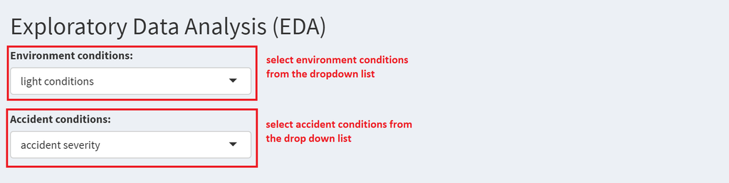

## Univariate Analysis on Accdident Count Distribution

After the selection of input variables, the app will run univariate analysis and return the accident count distribution based on the input selected.

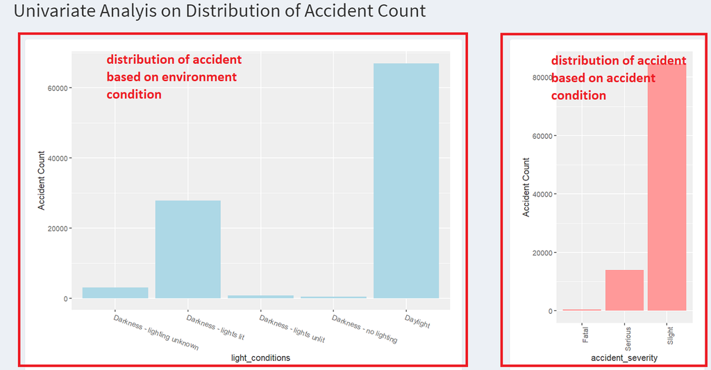

## Bivariate Chi-Square Analysis on Environment and Accident Conditions

Based on the above selected environment conditions (light conditions) and accident conditions (accident severity), the app will run chi-square test of independence on the two categorical variables. Test result below shows a small p-value and indicates a significant association between light conditions and accident severity.

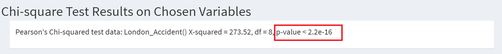

After the results of the chi-square test, the app will also display a balloon plot to visualise the frequency table used to run the chi-square test based on selected environment and accident conditions. The balloon plot draws a graphical matrix where each cell contains a dot whose size reflects the relative magnitude of the corresponding frequency.

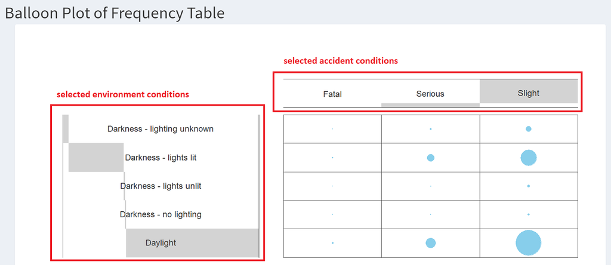

Next, the app will display a correlation plot on chi-square residuals based on selected environment and accident conditions. Positive residuals are in blue. Positive values in cells specify an attraction (positive association) between the corresponding environment and accident variables. Negative residuals are in red. This implies a repulsion (negative association) between the corresponding environment and accident variables.

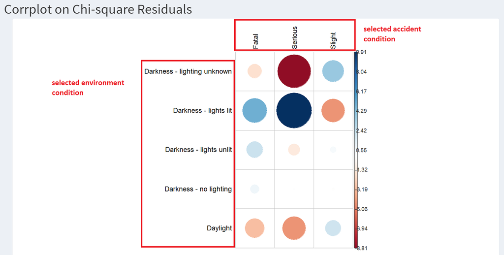

Last but not least, the raw frequency table generated based on selected environment and accident conditions will be desplayed for reference purposes.

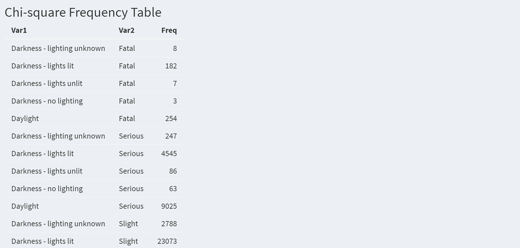

# 2. GeoVisual Analysis

# 3. Regression Analysis